# Data 607 Spring 2019 HW 9

#### Make sense of output with some plots

##### Among type of materials do articles on Dreamers tend to appear?

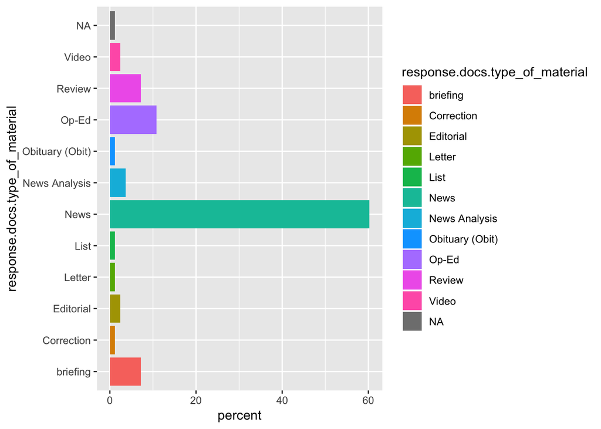

```r
# Visualize coverage of dreamers by type of material
dreamer_search %>%
  group_by(response.docs.type_of_material) %>%
  summarize(count=n()) %>%
  mutate(percent = (count / sum(count))*100) %>%
  ggplot() +
  geom_bar(aes(y=percent, x=response.docs.type_of_material, fill=response.docs.type_of_material), stat = "identity") + coord_flip()
```

Articles on Dreamers tend to be concentrated under the News materials then in the Op-ed materials From an initial glance at the results, the Review section is likely not referring to the Dreamers who are registered undocumented individuals living in the U.S.

##### What sections do Dreamer articles tend to appear?

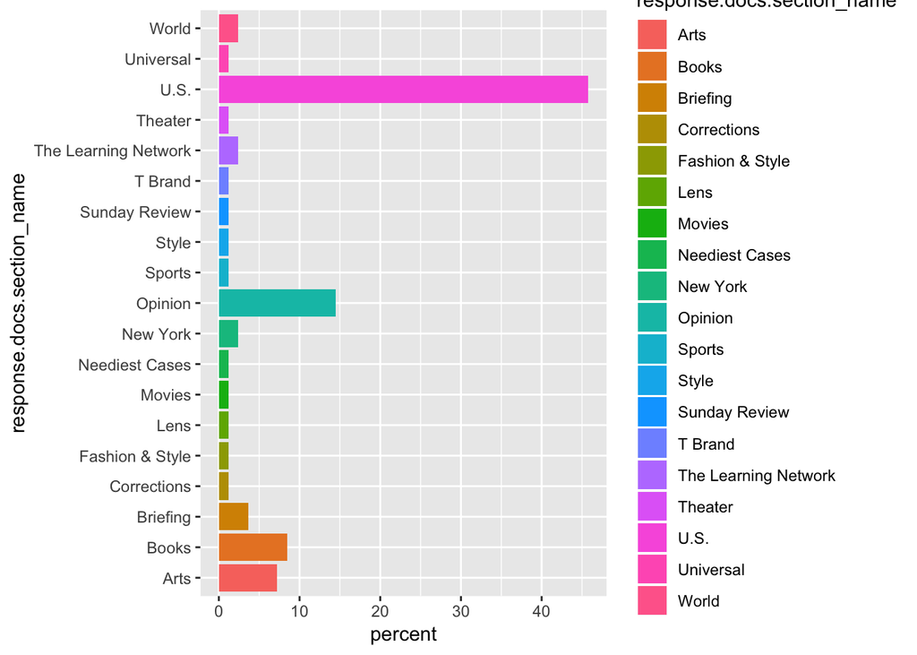

```r
# Visualize coverage of dreamers by section
dreamer_search %>%
  group_by(response.docs.section_name) %>%
  summarize(count=n()) %>%
  mutate(percent = (count / sum(count))*100) %>%
  ggplot() +
  geom_bar(aes(y=percent, x=response.docs.section_name, fill=response.docs.section_name), stat = "identity") + coord_flip()
```

We see that almost the majority of articles written on Dreamers is in the U.S. section. 14% of articles are in the Opinion section, then 8% in Books and 7% in Arts. The latter categories may be noise.

##### When were Dreamer articles more frequent in the last 3 months?

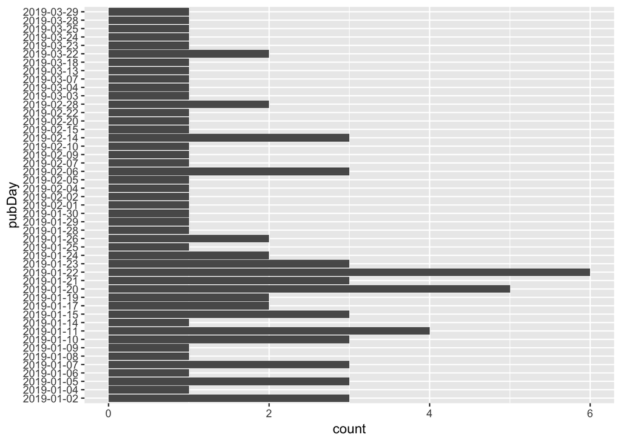

```r
# plot trends in how frequently dreamers are mentioned in the last 3 months
dreamer_search %>%
  mutate(pubDay=gsub("T.*","",response.docs.pub_date)) %>%
  group_by(pubDay) %>%
  summarise(count=n()) %>%
  mutate(date=ymd(pubDay)) %>%
  arrange(pubDay) %>%
  #filter(count >= 2) %>%
  ggplot() +
  geom_bar(aes(x=pubDay, y=count), stat="identity") + coord_flip()
```

We see spikes in the early second half of January, indicating that there may have been incidents regarding Dreamers earlier in the month. Since then, we see that there’s been fewer articles but still steady coverage in February and March. To posit a theory about the spike, it occurs after a series of political incidents, starting with Pres. Trump’s demand for funding for a border wall. He threatened a government shut-down if his demands were not met. In response, some Democrats responded by fighting for protections for Dreamers and DACA recipients. As such, the trends above may be reflecting the consequences of these political events.